# Risk Factor Analysis

## Outcome Variable

**Outcome Variable:** wasted

## Predictor Variables

**Intervention Variable:** mwtkg

**Adjustment Set:**

- arm
- W_mage
- meducyrs
- feducyrs
- single
- brthmon
- W_parity
- delta_W_mage
- delta_meducyrs
- delta_feducyrs
- delta_single
- delta_brthmon
- delta_W_parity

## Stratifying Variables

The analysis was stratified on these variable(s):

- agecat
- studyid
- country

## Data Summary

| agecat | studyid | country | mwtkg | wasted | n_cell | n |
| --- | --- | --- | --- | --- | --- | --- |
| Birth | ki0047075b-MAL-ED | BANGLADESH | >=58 kg | 0 | 34 | 209 |
| Birth | ki0047075b-MAL-ED | BANGLADESH | >=58 kg | 1 | 3 | 209 |
| Birth | ki0047075b-MAL-ED | BANGLADESH | <52 kg | 0 | 107 | 209 |
| Birth | ki0047075b-MAL-ED | BANGLADESH | <52 kg | 1 | 24 | 209 |
| Birth | ki0047075b-MAL-ED | BANGLADESH | [52-58) kg | 0 | 33 | 209 |
| Birth | ki0047075b-MAL-ED | BANGLADESH | [52-58) kg | 1 | 8 | 209 |
| Birth | ki0047075b-MAL-ED | BRAZIL | >=58 kg | 0 | 33 | 61 |
| Birth | ki0047075b-MAL-ED | BRAZIL | >=58 kg | 1 | 0 | 61 |
| Birth | ki0047075b-MAL-ED | BRAZIL | <52 kg | 0 | 13 | 61 |
| Birth | ki0047075b-MAL-ED | BRAZIL | <52 kg | 1 | 1 | 61 |
| Birth | ki0047075b-MAL-ED | BRAZIL | [52-58) kg | 0 | 13 | 61 |
| Birth | ki0047075b-MAL-ED | BRAZIL | [52-58) kg | 1 | 1 | 61 |
| Birth | ki0047075b-MAL-ED | INDIA | >=58 kg | 0 | 6 | 41 |
| Birth | ki0047075b-MAL-ED | INDIA | >=58 kg | 1 | 0 | 41 |
| Birth | ki0047075b-MAL-ED | INDIA | <52 kg | 0 | 23 | 41 |
| Birth | ki0047075b-MAL-ED | INDIA | <52 kg | 1 | 5 | 41 |
| Birth | ki0047075b-MAL-ED | INDIA | [52-58) kg | 0 | 7 | 41 |
| Birth | ki0047075b-MAL-ED | INDIA | [52-58) kg | 1 | 0 | 41 |
| Birth | ki0047075b-MAL-ED | NEPAL | >=58 kg | 0 | 9 | 26 |
| Birth | ki0047075b-MAL-ED | NEPAL | >=58 kg | 1 | 0 | 26 |
| Birth | ki0047075b-MAL-ED | NEPAL | <52 kg | 0 | 6 | 26 |
| Birth | ki0047075b-MAL-ED | NEPAL | <52 kg | 1 | 1 | 26 |
| Birth | ki0047075b-MAL-ED | NEPAL | [52-58) kg | 0 | 9 | 26 |
| Birth | ki0047075b-MAL-ED | NEPAL | [52-58) kg | 1 | 1 | 26 |
| Birth | ki0047075b-MAL-ED | PERU | >=58 kg | 0 | 80 | 221 |
| Birth | ki0047075b-MAL-ED | PERU | >=58 kg | 1 | 2 | 221 |
| Birth | ki0047075b-MAL-ED | PERU | <52 kg | 0 | 78 | 221 |
| Birth | ki0047075b-MAL-ED | PERU | <52 kg | 1 | 3 | 221 |
| Birth | ki0047075b-MAL-ED | PERU | [52-58) kg | 0 | 58 | 221 |
| Birth | ki0047075b-MAL-ED | PERU | [52-58) kg | 1 | 0 | 221 |

[output cut: 240 more lines]

The following strata were considered:

- agecat: 24 months, studyid: ki0047075b-MAL-ED, country: BANGLADESH
- agecat: 24 months, studyid: ki0047075b-MAL-ED, country: BRAZIL
- agecat: 24 months, studyid: ki0047075b-MAL-ED, country: INDIA
- agecat: 24 months, studyid: ki0047075b-MAL-ED, country: NEPAL
- agecat: 24 months, studyid: ki0047075b-MAL-ED, country: PERU
- agecat: 24 months, studyid: ki0047075b-MAL-ED, country: SOUTH AFRICA
- agecat: 24 months, studyid: ki0047075b-MAL-ED, country: TANZANIA, UNITED REPUBLIC OF
- agecat: 24 months, studyid: ki1017093-NIH-Birth, country: BANGLADESH
- agecat: 24 months, studyid: ki1017093b-PROVIDE, country: BANGLADESH
- agecat: 24 months, studyid: ki1017093c-NIH-Crypto, country: BANGLADESH
- agecat: 24 months, studyid: ki1066203-TanzaniaChild2, country: TANZANIA, UNITED REPUBLIC OF
- agecat: 24 months, studyid: ki1119695-PROBIT, country: BELARUS
- agecat: 24 months, studyid: ki1126311-ZVITAMBO, country: ZIMBABWE
- agecat: 24 months, studyid: ki1148112-LCNI-5, country: MALAWI
- agecat: 24 months, studyid: kiGH5241-JiVitA-3, country: BANGLADESH
- agecat: 6 months, studyid: ki0047075b-MAL-ED, country: BANGLADESH
- agecat: 6 months, studyid: ki0047075b-MAL-ED, country: BRAZIL
- agecat: 6 months, studyid: ki0047075b-MAL-ED, country: INDIA
- agecat: 6 months, studyid: ki0047075b-MAL-ED, country: NEPAL
- agecat: 6 months, studyid: ki0047075b-MAL-ED, country: PERU
- agecat: 6 months, studyid: ki0047075b-MAL-ED, country: SOUTH AFRICA
- agecat: 6 months, studyid: ki0047075b-MAL-ED, country: TANZANIA, UNITED REPUBLIC OF
- agecat: 6 months, studyid: ki1000304b-SAS-CompFeed, country: INDIA
- agecat: 6 months, studyid: ki1017093-NIH-Birth, country: BANGLADESH
- agecat: 6 months, studyid: ki1017093b-PROVIDE, country: BANGLADESH
- agecat: 6 months, studyid: ki1017093c-NIH-Crypto, country: BANGLADESH
- agecat: 6 months, studyid: ki1066203-TanzaniaChild2, country: TANZANIA, UNITED REPUBLIC OF
- agecat: 6 months, studyid: ki1119695-PROBIT, country: BELARUS
- agecat: 6 months, studyid: ki1126311-ZVITAMBO, country: ZIMBABWE
- agecat: 6 months, studyid: ki1148112-LCNI-5, country: MALAWI
- agecat: 6 months, studyid: kiGH5241-JiVitA-3, country: BANGLADESH
- agecat: Birth, studyid: ki0047075b-MAL-ED, country: BANGLADESH
- agecat: Birth, studyid: ki0047075b-MAL-ED, country: BRAZIL
- agecat: Birth, studyid: ki0047075b-MAL-ED, country: INDIA
- agecat: Birth, studyid: ki0047075b-MAL-ED, country: NEPAL
- agecat: Birth, studyid: ki0047075b-MAL-ED, country: PERU
- agecat: Birth, studyid: ki0047075b-MAL-ED, country: SOUTH AFRICA
- agecat: Birth, studyid: ki0047075b-MAL-ED, country: TANZANIA, UNITED REPUBLIC OF
- agecat: Birth, studyid: ki1000304b-SAS-CompFeed, country: INDIA
- agecat: Birth, studyid: ki1017093-NIH-Birth, country: BANGLADESH
- agecat: Birth, studyid: ki1017093b-PROVIDE, country: BANGLADESH
- agecat: Birth, studyid: ki1017093c-NIH-Crypto, country: BANGLADESH
- agecat: Birth, studyid: ki1119695-PROBIT, country: BELARUS
- agecat: Birth, studyid: ki1126311-ZVITAMBO, country: ZIMBABWE
- agecat: Birth, studyid: kiGH5241-JiVitA-3, country: BANGLADESH

### Dropped Strata

Some strata were dropped due to rare outcomes:

- agecat: Birth, studyid: ki0047075b-MAL-ED, country: BANGLADESH
- agecat: Birth, studyid: ki0047075b-MAL-ED, country: BRAZIL
- agecat: Birth, studyid: ki0047075b-MAL-ED, country: INDIA
- agecat: Birth, studyid: ki0047075b-MAL-ED, country: NEPAL
- agecat: Birth, studyid: ki0047075b-MAL-ED, country: PERU
- agecat: Birth, studyid: ki0047075b-MAL-ED, country: SOUTH AFRICA
- agecat: Birth, studyid: ki0047075b-MAL-ED, country: TANZANIA, UNITED REPUBLIC OF
- agecat: 6 months, studyid: ki0047075b-MAL-ED, country: BANGLADESH
- agecat: 6 months, studyid: ki0047075b-MAL-ED, country: BRAZIL
- agecat: 6 months, studyid: ki0047075b-MAL-ED, country: INDIA
- agecat: 6 months, studyid: ki0047075b-MAL-ED, country: NEPAL
- agecat: 6 months, studyid: ki0047075b-MAL-ED, country: PERU
- agecat: 6 months, studyid: ki0047075b-MAL-ED, country: SOUTH AFRICA
- agecat: 6 months, studyid: ki0047075b-MAL-ED, country: TANZANIA, UNITED REPUBLIC OF
- agecat: 6 months, studyid: ki1017093-NIH-Birth, country: BANGLADESH
- agecat: 6 months, studyid: ki1017093b-PROVIDE, country: BANGLADESH
- agecat: 6 months, studyid: ki1017093c-NIH-Crypto, country: BANGLADESH
- agecat: 6 months, studyid: ki1148112-LCNI-5, country: MALAWI
- agecat: 24 months, studyid: ki0047075b-MAL-ED, country: BANGLADESH
- agecat: 24 months, studyid: ki0047075b-MAL-ED, country: BRAZIL
- agecat: 24 months, studyid: ki0047075b-MAL-ED, country: INDIA
- agecat: 24 months, studyid: ki0047075b-MAL-ED, country: NEPAL
- agecat: 24 months, studyid: ki0047075b-MAL-ED, country: PERU
- agecat: 24 months, studyid: ki0047075b-MAL-ED, country: SOUTH AFRICA
- agecat: 24 months, studyid: ki0047075b-MAL-ED, country: TANZANIA, UNITED REPUBLIC OF
- agecat: 24 months, studyid: ki1017093-NIH-Birth, country: BANGLADESH
- agecat: 24 months, studyid: ki1066203-TanzaniaChild2, country: TANZANIA, UNITED REPUBLIC OF
- agecat: 24 months, studyid: ki1119695-PROBIT, country: BELARUS
- agecat: 24 months, studyid: ki1148112-LCNI-5, country: MALAWI

## Methods Detail

We’re interested in the causal parameters $E[Y_a]$ for all values of $a \in \mathcal{A}$. These parameters represent the mean outcome if, possibly contrary to fact, we intervened to set all units to have $A=a$. Under the randomization and positivity assumptions, these are identified by the statistical parameters $\psi_a=E_W[E_{Y|A,W}(Y|A=a,W)]$. In addition, we’re interested in the mean of $Y$, $E[Y]$ under no intervention (the observed mean). We will estimate these parameters by using SuperLearner to fit the relevant likelihood factors – $E_{Y|A,W}(Y|A=a,W)$ and $p(A=a|W)$, and then updating our likelihood fit using a joint TMLE.

For unadjusted analyses ($W=\{\}$), initial likelihoods were estimated using Lrnr_glm to estimate the simple $E(Y|A)$ and Lrnr_mean to estimate $p(A)$. For adjusted analyses, a small library containing Lrnr_glmnet, Lrnr_xgboost, and Lrnr_mean was used.

Having estimated these parameters, we will then use the delta method to estimate relative risks and attributable risks relative to a prespecified baseline level of $A$.

# Results Detail

## Results Plots

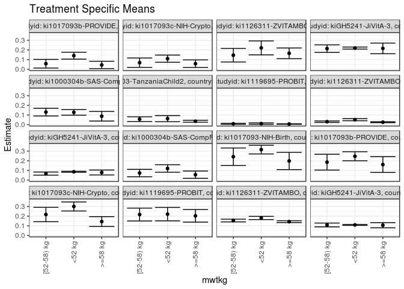

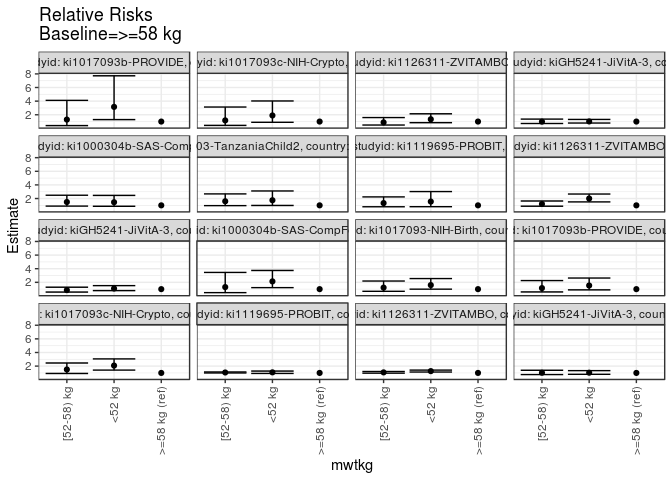

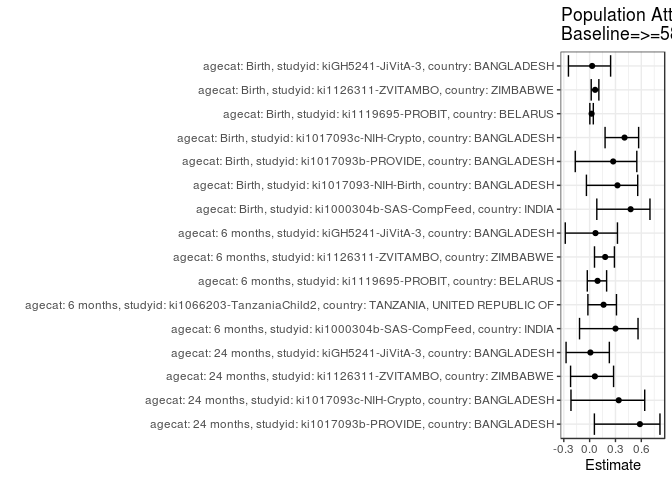

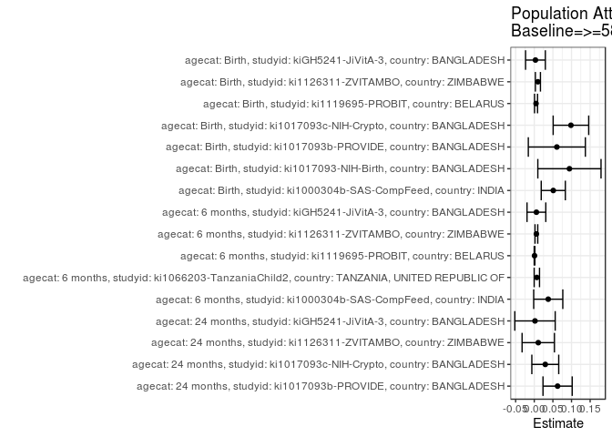

## Results Table

### Parameter: TSM

| agecat | studyid | country | intervention_level | baseline_level | estimate | ci_lower | ci_upper |
| --- | --- | --- | --- | --- | --- | --- | --- |
| Birth | ki1000304b-SAS-CompFeed | INDIA | >=58 kg | NA | 0.0561798 | 0.0184587 | 0.0939008 |
| Birth | ki1000304b-SAS-CompFeed | INDIA | <52 kg | NA | 0.1201456 | 0.0811367 | 0.1591546 |
| Birth | ki1000304b-SAS-CompFeed | INDIA | [52-58) kg | NA | 0.0730337 | 0.0346496 | 0.1114178 |
| Birth | ki1017093-NIH-Birth | BANGLADESH | >=58 kg | NA | 0.1977638 | 0.1088113 | 0.2867164 |
| Birth | ki1017093-NIH-Birth | BANGLADESH | <52 kg | NA | 0.3154566 | 0.2704720 | 0.3604411 |
| Birth | ki1017093-NIH-Birth | BANGLADESH | [52-58) kg | NA | 0.2417868 | 0.1518107 | 0.3317630 |
| Birth | ki1017093b-PROVIDE | BANGLADESH | >=58 kg | NA | 0.1609527 | 0.0794221 | 0.2424832 |
| Birth | ki1017093b-PROVIDE | BANGLADESH | <52 kg | NA | 0.2466898 | 0.2000130 | 0.2933666 |
| Birth | ki1017093b-PROVIDE | BANGLADESH | [52-58) kg | NA | 0.1856515 | 0.1038843 | 0.2674188 |
| Birth | ki1017093c-NIH-Crypto | BANGLADESH | >=58 kg | NA | 0.1444541 | 0.0934882 | 0.1954201 |
| Birth | ki1017093c-NIH-Crypto | BANGLADESH | <52 kg | NA | 0.3003894 | 0.2538347 | 0.3469441 |
| Birth | ki1017093c-NIH-Crypto | BANGLADESH | [52-58) kg | NA | 0.2171697 | 0.1428987 | 0.2914406 |
| Birth | ki1119695-PROBIT | BELARUS | >=58 kg | NA | 0.2038223 | 0.1385634 | 0.2690812 |
| Birth | ki1119695-PROBIT | BELARUS | <52 kg | NA | 0.2212864 | 0.1519167 | 0.2906561 |
| Birth | ki1119695-PROBIT | BELARUS | [52-58) kg | NA | 0.2170220 | 0.1505669 | 0.2834772 |
| Birth | ki1126311-ZVITAMBO | ZIMBABWE | >=58 kg | NA | 0.1435310 | 0.1340868 | 0.1529752 |
| Birth | ki1126311-ZVITAMBO | ZIMBABWE | <52 kg | NA | 0.1814984 | 0.1648349 | 0.1981619 |
| Birth | ki1126311-ZVITAMBO | ZIMBABWE | [52-58) kg | NA | 0.1549599 | 0.1408959 | 0.1690239 |
| Birth | kiGH5241-JiVitA-3 | BANGLADESH | >=58 kg | NA | 0.1063929 | 0.0795952 | 0.1331906 |
| Birth | kiGH5241-JiVitA-3 | BANGLADESH | <52 kg | NA | 0.1099470 | 0.1046357 | 0.1152584 |
| Birth | kiGH5241-JiVitA-3 | BANGLADESH | [52-58) kg | NA | 0.1092359 | 0.0896562 | 0.1288157 |
| 6 months | ki1000304b-SAS-CompFeed | INDIA | >=58 kg | NA | 0.0873787 | 0.0376907 | 0.1370666 |
| 6 months | ki1000304b-SAS-CompFeed | INDIA | <52 kg | NA | 0.1275964 | 0.0982369 | 0.1569559 |
| 6 months | ki1000304b-SAS-CompFeed | INDIA | [52-58) kg | NA | 0.1302326 | 0.0903997 | 0.1700654 |
| 6 months | ki1066203-TanzaniaChild2 | TANZANIA, UNITED REPUBLIC OF | >=58 kg | NA | 0.0358330 | 0.0255246 | 0.0461414 |
| 6 months | ki1066203-TanzaniaChild2 | TANZANIA, UNITED REPUBLIC OF | <52 kg | NA | 0.0627195 | 0.0313693 | 0.0940697 |
| 6 months | ki1066203-TanzaniaChild2 | TANZANIA, UNITED REPUBLIC OF | [52-58) kg | NA | 0.0573762 | 0.0328122 | 0.0819401 |
| 6 months | ki1119695-PROBIT | BELARUS | >=58 kg | NA | 0.0071588 | 0.0052856 | 0.0090319 |
| 6 months | ki1119695-PROBIT | BELARUS | <52 kg | NA | 0.0111457 | 0.0037206 | 0.0185709 |
| 6 months | ki1119695-PROBIT | BELARUS | [52-58) kg | NA | 0.0095356 | 0.0043264 | 0.0147449 |
| 6 months | ki1126311-ZVITAMBO | ZIMBABWE | >=58 kg | NA | 0.0258711 | 0.0210480 | 0.0306943 |
| 6 months | ki1126311-ZVITAMBO | ZIMBABWE | <52 kg | NA | 0.0518374 | 0.0407305 | 0.0629442 |
| 6 months | ki1126311-ZVITAMBO | ZIMBABWE | [52-58) kg | NA | 0.0309882 | 0.0231624 | 0.0388139 |
| 6 months | kiGH5241-JiVitA-3 | BANGLADESH | >=58 kg | NA | 0.0788252 | 0.0533614 | 0.1042889 |
| 6 months | kiGH5241-JiVitA-3 | BANGLADESH | <52 kg | NA | 0.0860809 | 0.0810391 | 0.0911227 |
| 6 months | kiGH5241-JiVitA-3 | BANGLADESH | [52-58) kg | NA | 0.0675146 | 0.0513658 | 0.0836634 |
| 24 months | ki1017093b-PROVIDE | BANGLADESH | >=58 kg | NA | 0.0446429 | 0.0063627 | 0.0829230 |
| 24 months | ki1017093b-PROVIDE | BANGLADESH | <52 kg | NA | 0.1408840 | 0.1050144 | 0.1767536 |
| 24 months | ki1017093b-PROVIDE | BANGLADESH | [52-58) kg | NA | 0.0576923 | 0.0128423 | 0.1025423 |
| 24 months | ki1017093c-NIH-Crypto | BANGLADESH | >=58 kg | NA | 0.0579710 | 0.0189437 | 0.0969984 |
| 24 months | ki1017093c-NIH-Crypto | BANGLADESH | <52 kg | NA | 0.1098901 | 0.0727545 | 0.1470257 |
| 24 months | ki1017093c-NIH-Crypto | BANGLADESH | [52-58) kg | NA | 0.0679612 | 0.0193093 | 0.1166131 |
| 24 months | ki1126311-ZVITAMBO | ZIMBABWE | >=58 kg | NA | 0.1650512 | 0.1097509 | 0.2203515 |
| 24 months | ki1126311-ZVITAMBO | ZIMBABWE | <52 kg | NA | 0.2211452 | 0.1489992 | 0.2932913 |
| 24 months | ki1126311-ZVITAMBO | ZIMBABWE | [52-58) kg | NA | 0.1455742 | 0.0754252 | 0.2157232 |
| 24 months | kiGH5241-JiVitA-3 | BANGLADESH | >=58 kg | NA | 0.2161057 | 0.1614068 | 0.2708047 |
| 24 months | kiGH5241-JiVitA-3 | BANGLADESH | <52 kg | NA | 0.2194222 | 0.2091479 | 0.2296966 |
| 24 months | kiGH5241-JiVitA-3 | BANGLADESH | [52-58) kg | NA | 0.2136361 | 0.1747059 | 0.2525662 |

### Parameter: E(Y)

| agecat | studyid | country | intervention_level | baseline_level | estimate | ci_lower | ci_upper |
| --- | --- | --- | --- | --- | --- | --- | --- |
| Birth | ki1000304b-SAS-CompFeed | INDIA | NA | NA | 0.1072411 | 0.0763212 | 0.1381609 |
| Birth | ki1017093-NIH-Birth | BANGLADESH | NA | NA | 0.2921739 | 0.2549711 | 0.3293768 |
| Birth | ki1017093b-PROVIDE | BANGLADESH | NA | NA | 0.2215686 | 0.1854897 | 0.2576475 |
| Birth | ki1017093c-NIH-Crypto | BANGLADESH | NA | NA | 0.2428977 | 0.2111977 | 0.2745977 |
| Birth | ki1119695-PROBIT | BELARUS | NA | NA | 0.2085796 | 0.1430705 | 0.2740887 |
| Birth | ki1126311-ZVITAMBO | ZIMBABWE | NA | NA | 0.1533152 | 0.1463521 | 0.1602782 |
| Birth | kiGH5241-JiVitA-3 | BANGLADESH | NA | NA | 0.1095860 | 0.1044555 | 0.1147165 |
| 6 months | ki1000304b-SAS-CompFeed | INDIA | NA | NA | 0.1249059 | 0.0994146 | 0.1503973 |
| 6 months | ki1066203-TanzaniaChild2 | TANZANIA, UNITED REPUBLIC OF | NA | NA | 0.0427565 | 0.0338612 | 0.0516519 |
| 6 months | ki1119695-PROBIT | BELARUS | NA | NA | 0.0078837 | 0.0058935 | 0.0098738 |
| 6 months | ki1126311-ZVITAMBO | ZIMBABWE | NA | NA | 0.0315660 | 0.0277605 | 0.0353714 |
| 6 months | kiGH5241-JiVitA-3 | BANGLADESH | NA | NA | 0.0845902 | 0.0797842 | 0.0893962 |
| 24 months | ki1017093b-PROVIDE | BANGLADESH | NA | NA | 0.1072664 | 0.0820169 | 0.1325160 |
| 24 months | ki1017093c-NIH-Crypto | BANGLADESH | NA | NA | 0.0875486 | 0.0630907 | 0.1120065 |
| 24 months | ki1126311-ZVITAMBO | ZIMBABWE | NA | NA | 0.1757720 | 0.1393702 | 0.2121737 |
| 24 months | kiGH5241-JiVitA-3 | BANGLADESH | NA | NA | 0.2180740 | 0.2082038 | 0.2279441 |

### Parameter: RR

| agecat | studyid | country | intervention_level | baseline_level | estimate | ci_lower | ci_upper |
| --- | --- | --- | --- | --- | --- | --- | --- |
| Birth | ki1000304b-SAS-CompFeed | INDIA | >=58 kg | >=58 kg | 1.0000000 | 1.0000000 | 1.000000 |
| Birth | ki1000304b-SAS-CompFeed | INDIA | <52 kg | >=58 kg | 2.1385922 | 1.2224537 | 3.741309 |
| Birth | ki1000304b-SAS-CompFeed | INDIA | [52-58) kg | >=58 kg | 1.3000000 | 0.4894687 | 3.452723 |
| Birth | ki1017093-NIH-Birth | BANGLADESH | >=58 kg | >=58 kg | 1.0000000 | 1.0000000 | 1.000000 |
| Birth | ki1017093-NIH-Birth | BANGLADESH | <52 kg | >=58 kg | 1.5951175 | 0.9955337 | 2.555815 |
| Birth | ki1017093-NIH-Birth | BANGLADESH | [52-58) kg | >=58 kg | 1.2226038 | 0.6827562 | 2.189303 |
| Birth | ki1017093b-PROVIDE | BANGLADESH | >=58 kg | >=58 kg | 1.0000000 | 1.0000000 | 1.000000 |
| Birth | ki1017093b-PROVIDE | BANGLADESH | <52 kg | >=58 kg | 1.5326856 | 0.8926353 | 2.631674 |
| Birth | ki1017093b-PROVIDE | BANGLADESH | [52-58) kg | >=58 kg | 1.1534543 | 0.5893826 | 2.257374 |
| Birth | ki1017093c-NIH-Crypto | BANGLADESH | >=58 kg | >=58 kg | 1.0000000 | 1.0000000 | 1.000000 |
| Birth | ki1017093c-NIH-Crypto | BANGLADESH | <52 kg | >=58 kg | 2.0794792 | 1.4141363 | 3.057862 |
| Birth | ki1017093c-NIH-Crypto | BANGLADESH | [52-58) kg | >=58 kg | 1.5033813 | 0.9199345 | 2.456866 |
| Birth | ki1119695-PROBIT | BELARUS | >=58 kg | >=58 kg | 1.0000000 | 1.0000000 | 1.000000 |
| Birth | ki1119695-PROBIT | BELARUS | <52 kg | >=58 kg | 1.0856830 | 0.9254927 | 1.273600 |
| Birth | ki1119695-PROBIT | BELARUS | [52-58) kg | >=58 kg | 1.0647610 | 0.9947320 | 1.139720 |
| Birth | ki1126311-ZVITAMBO | ZIMBABWE | >=58 kg | >=58 kg | 1.0000000 | 1.0000000 | 1.000000 |
| Birth | ki1126311-ZVITAMBO | ZIMBABWE | <52 kg | >=58 kg | 1.2645238 | 1.1294265 | 1.415781 |
| Birth | ki1126311-ZVITAMBO | ZIMBABWE | [52-58) kg | >=58 kg | 1.0796264 | 0.9652093 | 1.207607 |
| Birth | kiGH5241-JiVitA-3 | BANGLADESH | >=58 kg | >=58 kg | 1.0000000 | 1.0000000 | 1.000000 |
| Birth | kiGH5241-JiVitA-3 | BANGLADESH | <52 kg | >=58 kg | 1.0334060 | 0.7994747 | 1.335787 |
| Birth | kiGH5241-JiVitA-3 | BANGLADESH | [52-58) kg | >=58 kg | 1.0267221 | 0.7582055 | 1.390333 |
| 6 months | ki1000304b-SAS-CompFeed | INDIA | >=58 kg | >=58 kg | 1.0000000 | 1.0000000 | 1.000000 |
| 6 months | ki1000304b-SAS-CompFeed | INDIA | <52 kg | >=58 kg | 1.4602701 | 0.8663107 | 2.461459 |
| 6 months | ki1000304b-SAS-CompFeed | INDIA | [52-58) kg | >=58 kg | 1.4904390 | 0.8935130 | 2.486151 |
| 6 months | ki1066203-TanzaniaChild2 | TANZANIA, UNITED REPUBLIC OF | >=58 kg | >=58 kg | 1.0000000 | 1.0000000 | 1.000000 |
| 6 months | ki1066203-TanzaniaChild2 | TANZANIA, UNITED REPUBLIC OF | <52 kg | >=58 kg | 1.7503300 | 0.9833732 | 3.115455 |
| 6 months | ki1066203-TanzaniaChild2 | TANZANIA, UNITED REPUBLIC OF | [52-58) kg | >=58 kg | 1.6012113 | 0.9559994 | 2.681882 |
| 6 months | ki1119695-PROBIT | BELARUS | >=58 kg | >=58 kg | 1.0000000 | 1.0000000 | 1.000000 |
| 6 months | ki1119695-PROBIT | BELARUS | <52 kg | >=58 kg | 1.5569307 | 0.8011620 | 3.025647 |
| 6 months | ki1119695-PROBIT | BELARUS | [52-58) kg | >=58 kg | 1.3320224 | 0.7920174 | 2.240208 |
| 6 months | ki1126311-ZVITAMBO | ZIMBABWE | >=58 kg | >=58 kg | 1.0000000 | 1.0000000 | 1.000000 |
| 6 months | ki1126311-ZVITAMBO | ZIMBABWE | <52 kg | >=58 kg | 2.0036768 | 1.5082102 | 2.661911 |
| 6 months | ki1126311-ZVITAMBO | ZIMBABWE | [52-58) kg | >=58 kg | 1.1977896 | 0.8750894 | 1.639490 |
| 6 months | kiGH5241-JiVitA-3 | BANGLADESH | >=58 kg | >=58 kg | 1.0000000 | 1.0000000 | 1.000000 |
| 6 months | kiGH5241-JiVitA-3 | BANGLADESH | <52 kg | >=58 kg | 1.0920484 | 0.7869908 | 1.515354 |
| 6 months | kiGH5241-JiVitA-3 | BANGLADESH | [52-58) kg | >=58 kg | 0.8565107 | 0.5708921 | 1.285025 |
| 24 months | ki1017093b-PROVIDE | BANGLADESH | >=58 kg | >=58 kg | 1.0000000 | 1.0000000 | 1.000000 |
| 24 months | ki1017093b-PROVIDE | BANGLADESH | <52 kg | >=58 kg | 3.1558010 | 1.2901595 | 7.719263 |
| 24 months | ki1017093b-PROVIDE | BANGLADESH | [52-58) kg | >=58 kg | 1.2923077 | 0.4061679 | 4.111745 |
| 24 months | ki1017093c-NIH-Crypto | BANGLADESH | >=58 kg | >=58 kg | 1.0000000 | 1.0000000 | 1.000000 |
| 24 months | ki1017093c-NIH-Crypto | BANGLADESH | <52 kg | >=58 kg | 1.8956044 | 0.8924902 | 4.026169 |
| 24 months | ki1017093c-NIH-Crypto | BANGLADESH | [52-58) kg | >=58 kg | 1.1723301 | 0.4388000 | 3.132082 |
| 24 months | ki1126311-ZVITAMBO | ZIMBABWE | >=58 kg | >=58 kg | 1.0000000 | 1.0000000 | 1.000000 |
| 24 months | ki1126311-ZVITAMBO | ZIMBABWE | <52 kg | >=58 kg | 1.3398582 | 0.8393913 | 2.138716 |
| 24 months | ki1126311-ZVITAMBO | ZIMBABWE | [52-58) kg | >=58 kg | 0.8819940 | 0.4902412 | 1.586797 |
| 24 months | kiGH5241-JiVitA-3 | BANGLADESH | >=58 kg | >=58 kg | 1.0000000 | 1.0000000 | 1.000000 |
| 24 months | kiGH5241-JiVitA-3 | BANGLADESH | <52 kg | >=58 kg | 1.0153466 | 0.7851693 | 1.313002 |
| 24 months | kiGH5241-JiVitA-3 | BANGLADESH | [52-58) kg | >=58 kg | 0.9885719 | 0.7181885 | 1.360749 |

### Parameter: PAR

| agecat | studyid | country | intervention_level | baseline_level | estimate | ci_lower | ci_upper |
| --- | --- | --- | --- | --- | --- | --- | --- |
| Birth | ki1000304b-SAS-CompFeed | INDIA | >=58 kg | NA | 0.0510613 | 0.0186947 | 0.0834278 |
| Birth | ki1017093-NIH-Birth | BANGLADESH | >=58 kg | NA | 0.0944101 | 0.0095700 | 0.1792502 |
| Birth | ki1017093b-PROVIDE | BANGLADESH | >=58 kg | NA | 0.0606160 | -0.0159656 | 0.1371975 |
| Birth | ki1017093c-NIH-Crypto | BANGLADESH | >=58 kg | NA | 0.0984436 | 0.0507395 | 0.1461477 |
| Birth | ki1119695-PROBIT | BELARUS | >=58 kg | NA | 0.0047572 | 0.0007010 | 0.0088135 |
| Birth | ki1126311-ZVITAMBO | ZIMBABWE | >=58 kg | NA | 0.0097842 | 0.0029763 | 0.0165920 |
| Birth | kiGH5241-JiVitA-3 | BANGLADESH | >=58 kg | NA | 0.0031931 | -0.0233698 | 0.0297560 |
| 6 months | ki1000304b-SAS-CompFeed | INDIA | >=58 kg | NA | 0.0375273 | -0.0015559 | 0.0766105 |
| 6 months | ki1066203-TanzaniaChild2 | TANZANIA, UNITED REPUBLIC OF | >=58 kg | NA | 0.0069236 | -0.0002566 | 0.0141038 |
| 6 months | ki1119695-PROBIT | BELARUS | >=58 kg | NA | 0.0007249 | -0.0002061 | 0.0016559 |
| 6 months | ki1126311-ZVITAMBO | ZIMBABWE | >=58 kg | NA | 0.0056948 | 0.0019958 | 0.0093939 |
| 6 months | kiGH5241-JiVitA-3 | BANGLADESH | >=58 kg | NA | 0.0057650 | -0.0194491 | 0.0309791 |
| 24 months | ki1017093b-PROVIDE | BANGLADESH | >=58 kg | NA | 0.0626236 | 0.0234443 | 0.1018028 |
| 24 months | ki1017093c-NIH-Crypto | BANGLADESH | >=58 kg | NA | 0.0295776 | -0.0065257 | 0.0656810 |
| 24 months | ki1126311-ZVITAMBO | ZIMBABWE | >=58 kg | NA | 0.0107207 | -0.0327091 | 0.0541506 |
| 24 months | kiGH5241-JiVitA-3 | BANGLADESH | >=58 kg | NA | 0.0019682 | -0.0522589 | 0.0561954 |

### Parameter: PAF

| agecat | studyid | country | intervention_level | baseline_level | estimate | ci_lower | ci_upper |
| --- | --- | --- | --- | --- | --- | --- | --- |
| Birth | ki1000304b-SAS-CompFeed | INDIA | >=58 kg | NA | 0.4761356 | 0.0833933 | 0.7005980 |
| Birth | ki1017093-NIH-Birth | BANGLADESH | >=58 kg | NA | 0.3231297 | -0.0372544 | 0.5583018 |
| Birth | ki1017093b-PROVIDE | BANGLADESH | >=58 kg | NA | 0.2735765 | -0.1669184 | 0.5477909 |
| Birth | ki1017093c-NIH-Crypto | BANGLADESH | >=58 kg | NA | 0.4052882 | 0.1793456 | 0.5690243 |
| Birth | ki1119695-PROBIT | BELARUS | >=58 kg | NA | 0.0228078 | 0.0025068 | 0.0426957 |
| Birth | ki1126311-ZVITAMBO | ZIMBABWE | >=58 kg | NA | 0.0638173 | 0.0184249 | 0.1071106 |
| Birth | kiGH5241-JiVitA-3 | BANGLADESH | >=58 kg | NA | 0.0291379 | -0.2461141 | 0.2435900 |
| 6 months | ki1000304b-SAS-CompFeed | INDIA | >=58 kg | NA | 0.3004444 | -0.1172838 | 0.5619931 |
| 6 months | ki1066203-TanzaniaChild2 | TANZANIA, UNITED REPUBLIC OF | >=58 kg | NA | 0.1619301 | -0.0202415 | 0.3115737 |
| 6 months | ki1119695-PROBIT | BELARUS | >=58 kg | NA | 0.0919475 | -0.0271987 | 0.1972737 |
| 6 months | ki1126311-ZVITAMBO | ZIMBABWE | >=58 kg | NA | 0.1804109 | 0.0564894 | 0.2880564 |
| 6 months | kiGH5241-JiVitA-3 | BANGLADESH | >=58 kg | NA | 0.0681521 | -0.2829160 | 0.3231509 |
| 24 months | ki1017093b-PROVIDE | BANGLADESH | >=58 kg | NA | 0.5838134 | 0.0552311 | 0.8166628 |
| 24 months | ki1017093c-NIH-Crypto | BANGLADESH | >=58 kg | NA | 0.3378422 | -0.2166810 | 0.6396320 |
| 24 months | ki1126311-ZVITAMBO | ZIMBABWE | >=58 kg | NA | 0.0609923 | -0.2212688 | 0.2780169 |
| 24 months | kiGH5241-JiVitA-3 | BANGLADESH | >=58 kg | NA | 0.0090255 | -0.2735968 | 0.2289315 |